# Bnlearn for Python

Welcome to the notebook of **bnlearn**. bnlearn is Python package for learning the graphical structure of Bayesian networks, parameter learning, inference and sampling methods. Because probabilistic graphical models can be difficult in usage, Bnlearn for python (this package) is build on the pgmpy package and contains the most-wanted pipelines. Navigate to API documentations for more detailed information.

The core functionalities are:  
* Causal Discovery  
* Structure Learning  
* Parameter Learning  
* Inferences using do-calculus

### Read the Medium blogs.

[1. A Step-by-Step Guide in detecting causal relationships using Bayesian Structure Learning in Python](https://towardsdatascience.com/a-step-by-step-guide-in-detecting-causal-relationships-using-bayesian-structure-learning-in-python-c20c6b31cee5)

[2. A step-by-step guide in designing knowledge-driven models using Bayesian theorem.](https://towardsdatascience.com/a-step-by-step-guide-in-designing-knowledge-driven-models-using-bayesian-theorem-7433f6fd64be)

[3. The Power of Bayesian Causal Inference: A Comparative Analysis of Libraries to Reveal Hidden Causality in Your Dataset.](https://towardsdatascience.com/the-power-of-bayesian-causal-inference-a-comparative-analysis-of-libraries-to-reveal-hidden-d91e8306e25e)

[4. Chat with Your Dataset using Bayesian Inferences.](https://towardsdatascience.com/chat-with-your-dataset-using-bayesian-inferences-bfd4dc7f8dcd)

### Support

This library is for free but it runs on coffee! :)

You can [support](https://erdogant.github.io/pca/pages/html/Documentation.html) in various ways, have a look at the [sponser page](https://erdogant.github.io/bnlearn/pages/html/Documentation.html). Report bugs, issues and feature extensions at [github page](https://github.com/erdogant/bnlearn).

```python
# Package installeren
!pip install bnlearn
!pip install distfit
```

```
Downloading distfit-1.8.6-py3-none-any.whl (40 kB)
   ━━━━━━━━━━━━━━━━━━━━━━━━━━━━━━━━━━━━━━━━ 40.9/40.9 kB 3.1 MB/s eta 0:00:00
Downloading colourmap-1.1.21-py3-none-any.whl (10 kB)
```

```python
# Importeer de package
from distfit import distfit
import bnlearn as bn
print(bn.__version__)
import pandas as pd
import numpy as np
import matplotlib.pyplot as plt
```

```
0.11.1
```

```python
# Import library
import bnlearn as bn

# Load dataset
df = bn.import_example('predictive_maintenance')

df.head()
```

|  | UDI | Product ID | Type | Air temperature [K] | Process temperature [K] | Rotational speed [rpm] | Torque [Nm] | Tool wear [min] | Machine failure | TWF | HDF | PWF | OSF | RNF |
| --- | --- | --- | --- | --- | --- | --- | --- | --- | --- | --- | --- | --- | --- | --- |
| 0 | 1 | M14860 | M | 298.1 | 308.6 | 1551 | 42.8 | 0 | 0 | 0 | 0 | 0 | 0 | 0 |
| 1 | 2 | L47181 | L | 298.2 | 308.7 | 1408 | 46.3 | 3 | 0 | 0 | 0 | 0 | 0 | 0 |
| 2 | 3 | L47182 | L | 298.1 | 308.5 | 1498 | 49.4 | 5 | 0 | 0 | 0 | 0 | 0 | 0 |
| 3 | 4 | L47183 | L | 298.2 | 308.6 | 1433 | 39.5 | 7 | 0 | 0 | 0 | 0 | 0 | 0 |
| 4 | 5 | L47184 | L | 298.2 | 308.7 | 1408 | 40.0 | 9 | 0 | 0 | 0 | 0 | 0 | 0 |

```python
# Remove IDs from Dataframe
del df['UDI']
del df['Product ID']
```

[output not shown]

[output cut: 80 more lines]

[output not shown]

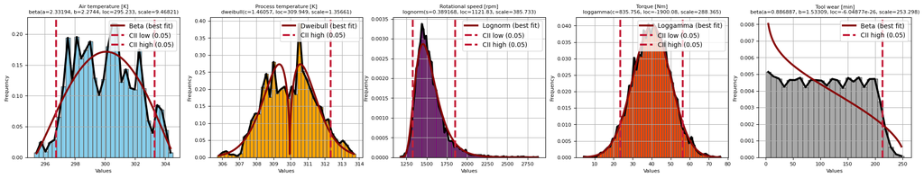

```python
# Discretize the following columns
colnames = ['Air temperature [K]', 'Process temperature [K]', 'Rotational speed [rpm]', 'Torque [Nm]', 'Tool wear [min]']
colors = ['#87CEEB', '#FFA500', '#800080', '#FF4500', '#A9A9A9']

fig, axes = plt.subplots(1, len(colnames), figsize=(5 * len(colnames), 4))  # adjust figsize as needed

# Apply distribution fitting to each variable
for idx, (colname, color) in enumerate(zip(colnames, colors)):
    # Initialize and set 95% confidence interval
    if colname=='Tool wear [min]' or colname=='Process temperature [K]':
        # Set model parameters to determine the medium-high ranges
        dist = distfit(alpha=0.05, bound='up', stats='RSS')
        labels = ['medium', 'high']
    else:
        # Set model parameters to determine the low-medium-high ranges
        dist = distfit(alpha=0.05, stats='RSS')
        labels = ['low', 'medium', 'high']

    # Distribution fitting
    dist.fit_transform(df[colname])

    # Plot
    dist.plot(title=colname, bar_properties={'color': color}, ax=axes[idx], fontsize=8)

    # Define bins based on distribution
    bins = [df[colname].min(), dist.model['CII_min_alpha'], dist.model['CII_max_alpha'], df[colname].max()]
    # Remove None
    bins = [x for x in bins if x is not None]

    # Discretize using the defined bins and add to dataframe
    df[colname + '_category'] = pd.cut(df[colname], bins=bins, labels=labels, include_lowest=True)
    # Delete the original column
    del df[colname]
```

```python
# Structure learning
model = bn.structure_learning.fit(df, methodtype='hc', scoretype='bic')
# [bnlearn] >Warning: Computing DAG with 12 nodes can take a very long time!
# [bnlearn] >Computing best DAG using [hc]
# [bnlearn] >Set scoring type at [bds]
# [bnlearn] >Compute structure scores for model comparison (higher is better).

print(model['structure_scores'])
# {'k2': -23261.534992034045,
# 'bic': -23296.9910477033,
# 'bdeu': -23325.348497769708,
# 'bds': -23397.741317668322}
```

```
[bnlearn] >Warning: Computing DAG with 12 nodes can take a very long time!
[bnlearn] >Computing best DAG using [hc]
[bnlearn] >Set scoring type at [bic]
[bnlearn] >Compute structure scores for model comparison (higher is better).
{'k2': -22648.785589229912, 'bic': -22717.975709504244, 'bdeu': -22696.58525478851, 'bds': -22795.52799206102}
```

```python
# Compute edge weights using ChiSquare independence test.
model = bn.independence_test(model, df, test='chi_square', prune=True)

# Plot the best DAG
# bn.plot(model, edge_labels='p_value', params_static={'maxscale': 4, 'figsize': (6, 6), 'font_size': 6, 'arrowsize': 6})

dotgraph = bn.plot_graphviz(model, edge_labels='p_value')
dotgraph

# Store to pdf
#dotgraph.view(filename='bnlearn_predictive_maintanance')
```

```
[06-05-2025 08:49:59] [setgraphviz.setgraphviz] [INFO] The OS is not supported to automatically set Graphviz in the system env.
[06-05-2025 08:49:59] [setgraphviz.setgraphviz] [INFO] Graphviz path found in environment.
```

```
[bnlearn] >Compute edge strength with [chi_square]
[bnlearn] >Setting edge labels to pvalue.
[bnlearn] >Converting source-target into adjacency matrix..
[bnlearn] >Making the matrix symmetric..
```

[figure not shown]

## How do I know my causal model is right?

If you solely used data to compute the causal diagram, it is hard to fully verify the validity and completeness of your causal diagram. However, some solutions can help to get more trust in the causal diagram. For example, it may be possible to empirically test certain conditional independence or dependence relationships between sets of variables. If they are not in the data, it is an indication of the correctness of the causal model. Alternatively, prior expert knowledge can be added, such as a DAG or CPTs, to get more trust in the model when making inferences.

A weakness of Bayesian networks is that finding the optimum DAG is computationally expensive since an exhaustive search over all the possible structures must be performed. The limit of nodes for exhaustive search can already be around 15 nodes but also depends on the number of states. If you have more nodes, alternative methods with a scoring function and search algorithm are required. Nevertheless, to deal with problems with hundreds or maybe even thousands of variables, a different approach, such as tree-based or constraint-based approaches is necessary with the use of black/whitelisting of variables. Such an approach first determines the order and then finds the optimal BN structure for that ordering. This implies working on the search space of the possible orderings, which is convenient as it is smaller than the space of network structures.

```python
# Learn inference model
model = bn.parameter_learning.fit(model, df, methodtype="bayes")
```

[output not shown]

[output cut: 53 more lines]

```
| Type(L) | 0.5844709350765879  | 0.42419175027870676 |
+---------+---------------------+---------------------+
| Type(M) | 0.3032750112157918  | 0.29375696767001114 |
+---------+---------------------+---------------------+
[bnlearn] >CPD of Rotational speed [rpm]_category:
+-----+------------------------------+
| ... | Torque [Nm]_category(medium) |
+-----+------------------------------+
| ... | 0.020443335116182324         |
+-----+------------------------------+
| ... | 0.03295893504486836          |
+-----+------------------------------+
| ... | 0.9465977298389493           |
+-----+------------------------------+
[bnlearn] >Compute structure scores for model comparison (higher is better).
```

```
[bnlearn] >Variable Elimination.
+----+-------------------+----------+
|    |   Machine failure |        p |
+====+===================+==========+
|  0 |                 0 | 0.584588 |
+----+-------------------+----------+
|  1 |                 1 | 0.415412 |
+----+-------------------+----------+
```

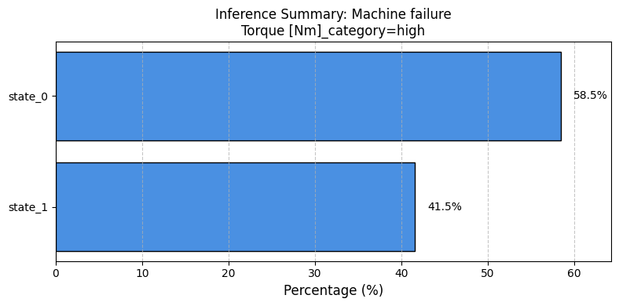

```
Summary for variables: ['Machine failure']
Given evidence: Torque [Nm]_category=high

Machine failure outcomes:
- Machine failure: 0 (58.5%)
- Machine failure: 1 (41.5%)
```

```python
q = bn.inference.fit(model, variables=['Machine failure'],
                      evidence={'Torque [Nm]_category': 'high'},
                      plot=True)
```

```
[bnlearn] >Variable Elimination.
+----+-------+-----------+
|    |   HDF |         p |
+====+=======+===========+
|  0 |     0 | 0.972256  |
+----+-------+-----------+
|  1 |     1 | 0.0277441 |
+----+-------+-----------+
```

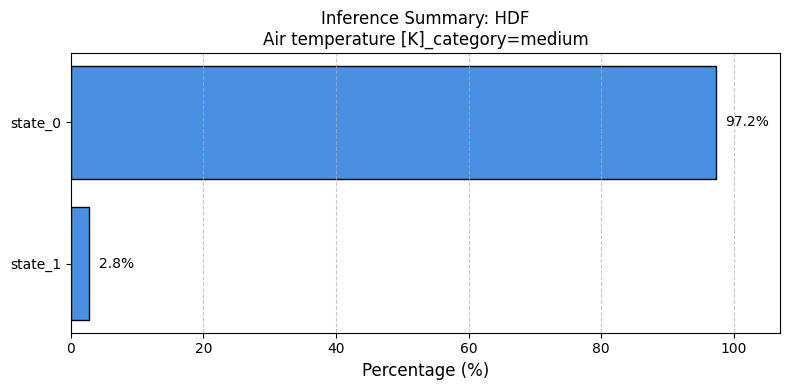

```
Summary for variables: ['HDF']
Given evidence: Air temperature [K]_category=medium

HDF outcomes:
- HDF: 0 (97.2%)
- HDF: 1 (2.8%)
```

```python
q = bn.inference.fit(model, variables=['HDF'],
                      evidence={'Air temperature [K]_category': 'medium'},
                      plot=True)
```

```
[bnlearn] >Variable Elimination.
+----+-------+-------+-------+-------+-------------+
|    |   TWF |   HDF |   PWF |   OSF |           p |
+====+=======+=======+=======+=======+=============+
|  0 |     0 |     0 |     0 |     0 | 0.0240521   |
+----+-------+-------+-------+-------+-------------+
|  1 |     0 |     0 |     0 |     1 | 0.210243    |
+----+-------+-------+-------+-------+-------------+
|  2 |     0 |     0 |     1 |     0 | 0.207443    |
+----+-------+-------+-------+-------+-------------+
|  3 |     0 |     0 |     1 |     1 | 0.0321357   |
+----+-------+-------+-------+-------+-------------+
|  4 |     0 |     1 |     0 |     0 | 0.245374    |
+----+-------+-------+-------+-------+-------------+
|  5 |     0 |     1 |     0 |     1 | 0.0177909   |
+----+-------+-------+-------+-------+-------------+
|  6 |     0 |     1 |     1 |     0 | 0.0185796   |
+----+-------+-------+-------+-------+-------------+
|  7 |     0 |     1 |     1 |     1 | 0.00499062  |
+----+-------+-------+-------+-------+-------------+
|  8 |     1 |     0 |     0 |     0 | 0.21378     |
+----+-------+-------+-------+-------+-------------+
|  9 |     1 |     0 |     0 |     1 | 0.00727977  |
+----+-------+-------+-------+-------+-------------+
| 10 |     1 |     0 |     1 |     0 | 0.00693896  |
+----+-------+-------+-------+-------+-------------+
| 11 |     1 |     0 |     1 |     1 | 0.00148291  |
+----+-------+-------+-------+-------+-------------+
| 12 |     1 |     1 |     0 |     0 | 0.00786678  |
+----+-------+-------+-------+-------+-------------+
| 13 |     1 |     1 |     0 |     1 | 0.000854361 |
+----+-------+-------+-------+-------+-------------+
| 14 |     1 |     1 |     1 |     0 | 0.000927891 |
+----+-------+-------+-------+-------+-------------+
| 15 |     1 |     1 |     1 |     1 | 0.000260654 |
+----+-------+-------+-------+-------+-------------+
```

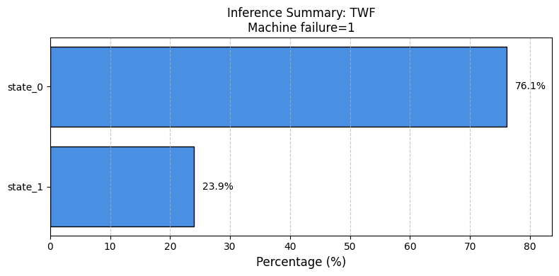

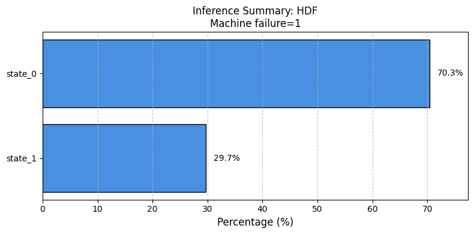

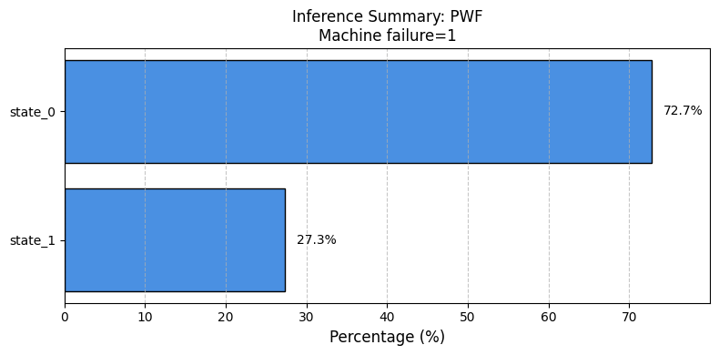

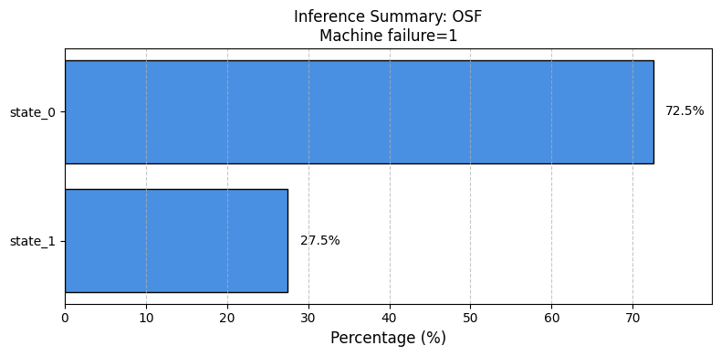

```
Summary for variables: ['TWF', 'HDF', 'PWF', 'OSF']
Given evidence: Machine failure=1

TWF outcomes:
- TWF: 0 (76.1%)
- TWF: 1 (23.9%)

HDF outcomes:
- HDF: 0 (70.3%)
- HDF: 1 (29.7%)

PWF outcomes:
- PWF: 0 (72.7%)
- PWF: 1 (27.3%)

OSF outcomes:
- OSF: 0 (72.5%)
- OSF: 1 (27.5%)
```

```python
q = bn.inference.fit(model, variables=['TWF', 'HDF', 'PWF', 'OSF'],
                      evidence={'Machine failure': 1},
                       plot=True)
```

# Summary

In summary, we moved from a RAW dataset to a DAG, which enabled us to go beyond descriptive statistics to prescriptive analysis. I demonstrated a data-driven approach to learn the causal structure of a dataset and to identify which aspects of the system can be adjusted to improve and reduce failure rates. Before making interventions, we also must perform inferences, which give us the updated probabilities when we fix (or observe) certain variables. Without this step, the intervention is just guessing because actions in one part of the system often ripple through and affect others (interdependence). This interconnectedness is exactly why understanding causal relationships is so important.

## Support

This library is for free but it runs on coffee! :)

You can [support](https://erdogant.github.io/pca/pages/html/Documentation.html) in various ways, have a look at the [sponser page](https://erdogant.github.io/bnlearn/pages/html/Documentation.html). Report bugs, issues and feature extensions at [github page](https://github.com/erdogant/bnlearn).